# Nonlinear Spline Toluene & NHANES

Hajin Jang

2/24/2024

### This project explores non-linear relationships and model selection strategies using spline-based regression, diagnostics, and cross-validation, applied to both experimental toluene data and NHANES data.

```r
library(tidyverse)
library(here)
library(car)
library(psych)
library(MASS)
library(lspline)
library(splines)
library(readxl)
library(glmnet)
library(olsrr)
```

# Part 1: Blood Toluene

## Data Management

```r
# read in data
toluene <- read.csv("toluene.csv")
toluene = toluene %>% mutate(snoutsize_f = factor(snoutsize, levels = c(1, 2), labels = c("short", "long")))
```

## 1. SLR model

**Fitting a simple linear model with bloodtol as the dependent variable and newppm as the independent variable.**

```r
# linear model
fit <- lm(bloodtol ~ newppm, data=toluene)
summary(fit)
```

```
##
## Call:
## lm(formula = bloodtol ~ newppm, data = toluene)
##
## Residuals:
##     Min      1Q  Median      3Q     Max
## -23.688  -2.340  -1.550   1.208  25.635
##
## Coefficients:
##             Estimate Std. Error t value Pr(>|t|)
## (Intercept)  0.76422    1.13233   0.675    0.502
## newppm       0.03501    0.00266  13.163   <2e-16 ***
## ---
## Signif. codes:  0 '***' 0.001 '**' 0.01 '*' 0.05 '.' 0.1 ' ' 1
##
## Residual standard error: 6.374 on 58 degrees of freedom
## Multiple R-squared:  0.7492, Adjusted R-squared:  0.7449
## F-statistic: 173.3 on 1 and 58 DF,  p-value: < 2.2e-16
```

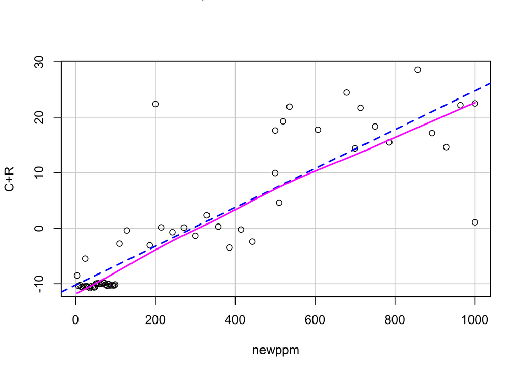

```r
# C+R plot
crPlots(fit, ylab = "C+R")
```

**Comment:** Points from the C+R plot are clustered in the 0 to 100 newppm, meaning that the relationship of newppm with bloodtol is not linear.

## 2. LOESS curve

**Fitting a LOESS curve over the scatterplot of blood toluene on toluene exposure.**

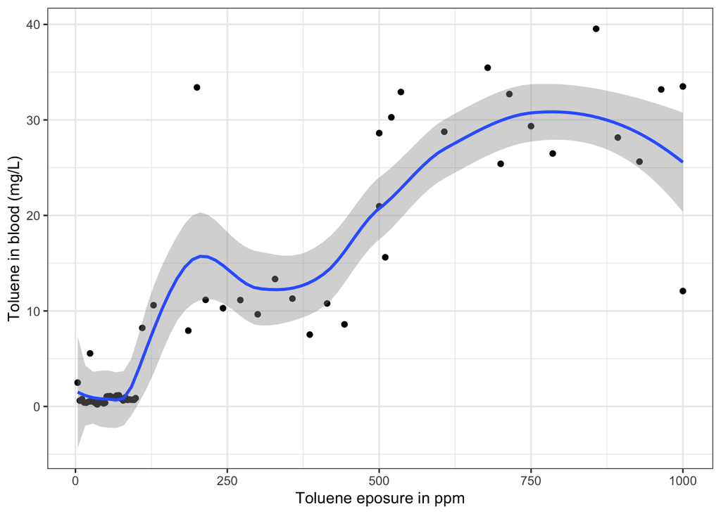

```r
# loess curve plot
toluene %>%
  ggplot(aes(x = newppm, y = bloodtol)) +
  theme_bw() +
  geom_point() +
  geom_smooth(method = "loess", span = .5) +
  labs(x = "Toluene eposure in ppm", y = "Toluene in blood (mg/L)") +
  theme(legend.position = "none")
```

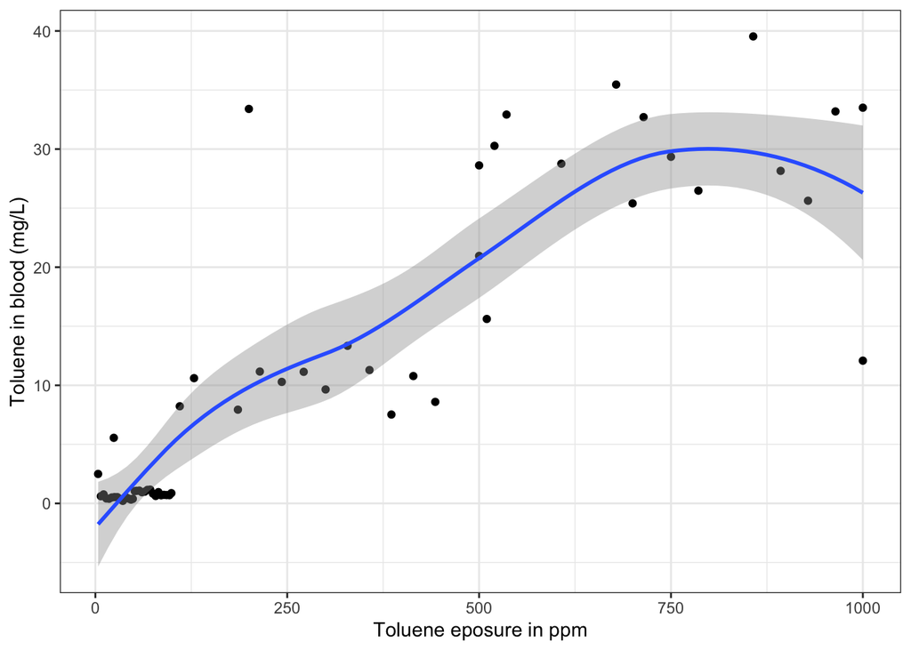

```r
toluene %>%
  ggplot(aes(x = newppm, y = bloodtol)) +
  theme_bw() +
  geom_point() +
  geom_smooth(method = "loess", span = .75) +
  labs(x = "Toluene eposure in ppm", y = "Toluene in blood (mg/L)") +
  theme(legend.position = "none")
```

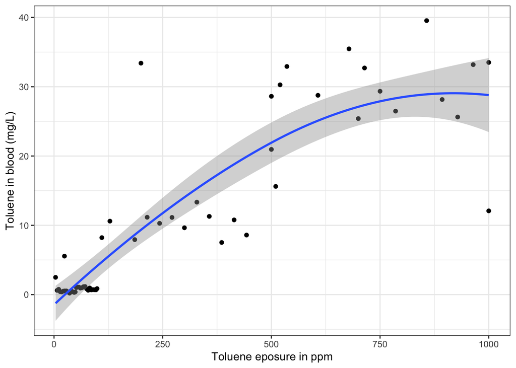

```r
toluene %>%
  ggplot(aes(x = newppm, y = bloodtol)) +
  theme_bw() +
  geom_point() +
  geom_smooth(method = "loess", span = 2) +
  labs(x = "Toluene eposure in ppm", y = "Toluene in blood (mg/L)") +
  theme(legend.position = "none")
```

**Comment:** The plots showed an overall positive association between toluene exposure and blood toluene. As the span increases, the plots become smoother. This is because using a larger neighborhood would yield a smoother curve while using a smaller neighborhood would yield a choppier curve.

## 3. Linear spline model

**Fitting a model with linear splines using knots at newppm values of 125, 375, and 625.**

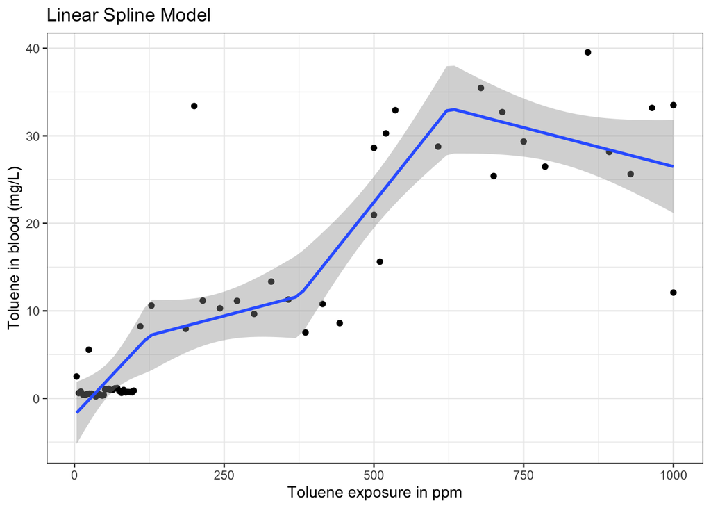

```r
# linear spline plot
spline.lin.t = lm(bloodtol ~ lspline(newppm, knots = c(125, 375, 625),marginal = T), data = toluene)

toluene %>%
  mutate(pred = predict(spline.lin.t)) %>%
  ggplot(aes(x = newppm, y = bloodtol)) +
  theme_bw() +
  geom_point() +
  labs(y = "Toluene in blood (mg/L)",
       x = "Toluene exposure in ppm",
       title = "Linear Spline Model") +
  geom_smooth(method = "lm",
              formula = y ~ lspline(x, knots = c(125, 375, 625),marginal = T))
```

```r
# show output
summary(spline.lin.t)
```

```
##
## Call:
## lm(formula = bloodtol ~ lspline(newppm, knots = c(125, 375, 625),
##     marginal = T), data = toluene)
##
## Residuals:
##      Min       1Q   Median       3Q      Max
## -14.4022  -2.7426  -0.5662   1.9372  24.8764
##
## Coefficients:
##                                                          Estimate Std. Error
## (Intercept)                                              -1.92817    1.85437
## lspline(newppm, knots = c(125, 375, 625), marginal = T)1  0.07284    0.02740
## lspline(newppm, knots = c(125, 375, 625), marginal = T)2 -0.05488    0.03828
## lspline(newppm, knots = c(125, 375, 625), marginal = T)3  0.06800    0.02757
## lspline(newppm, knots = c(125, 375, 625), marginal = T)4 -0.10376    0.02524
##                                                          t value Pr(>|t|)
## (Intercept)                                               -1.040 0.302982
## lspline(newppm, knots = c(125, 375, 625), marginal = T)1   2.658 0.010267 *
## lspline(newppm, knots = c(125, 375, 625), marginal = T)2  -1.434 0.157294
## lspline(newppm, knots = c(125, 375, 625), marginal = T)3   2.467 0.016784 *
## lspline(newppm, knots = c(125, 375, 625), marginal = T)4  -4.110 0.000133 ***
## ---
## Signif. codes:  0 '***' 0.001 '**' 0.01 '*' 0.05 '.' 0.1 ' ' 1
##
## Residual standard error: 5.469 on 55 degrees of freedom
## Multiple R-squared:  0.8249, Adjusted R-squared:  0.8121
## F-statistic: 64.76 on 4 and 55 DF,  p-value: < 2.2e-16
```

## 4. Marginal vs not marginal splines

**Fitting a second model without marginal coefficients.**

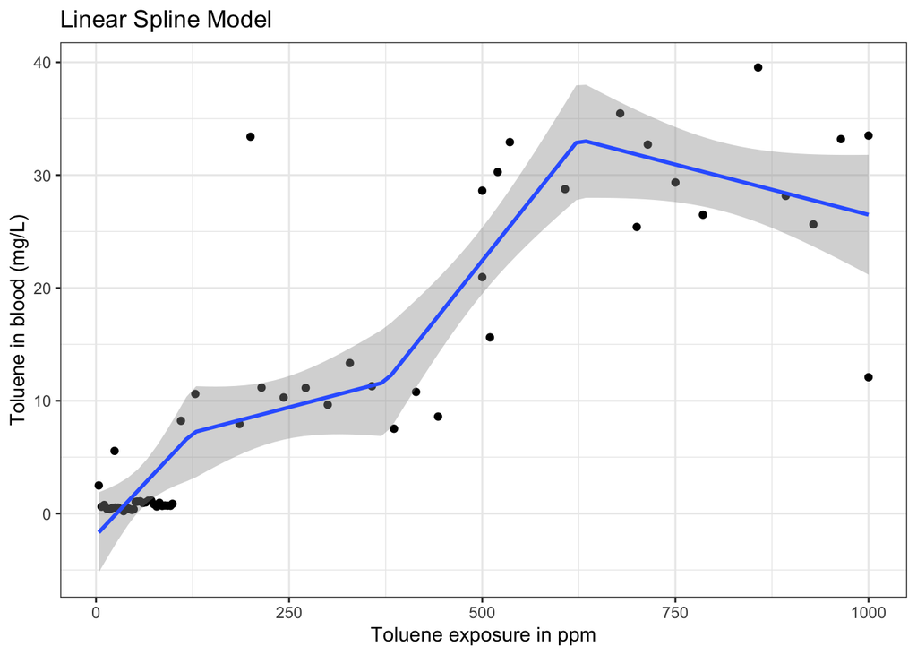

```r
# linear splines without marginal = T (with marginal = F)
spline.lin.f = lm(bloodtol ~ lspline(newppm, knots = c(125, 375, 625),marginal = F), data = toluene)

toluene %>%
  mutate(pred = predict(spline.lin.f)) %>%
  ggplot(aes(x = newppm, y = bloodtol)) +
  theme_bw() +
  geom_point() +
  labs(y = "Toluene in blood (mg/L)",
       x = "Toluene exposure in ppm",
       title = "Linear Spline Model") +
  geom_smooth(method = "lm",
              formula = y ~ lspline(x, knots = c(125, 375, 625),marginal = F))
```

```r
# show output
summary(spline.lin.f)
```

```
##
## Call:
## lm(formula = bloodtol ~ lspline(newppm, knots = c(125, 375, 625),
##     marginal = F), data = toluene)
##
## Residuals:
##      Min       1Q   Median       3Q      Max
## -14.4022  -2.7426  -0.5662   1.9372  24.8764
##
## Coefficients:
##                                                          Estimate Std. Error
## (Intercept)                                              -1.92817    1.85437
## lspline(newppm, knots = c(125, 375, 625), marginal = F)1  0.07284    0.02740
## lspline(newppm, knots = c(125, 375, 625), marginal = F)2  0.01796    0.01411
## lspline(newppm, knots = c(125, 375, 625), marginal = F)3  0.08597    0.01618
## lspline(newppm, knots = c(125, 375, 625), marginal = F)4 -0.01779    0.01138
##                                                          t value Pr(>|t|)
## (Intercept)                                               -1.040   0.3030
## lspline(newppm, knots = c(125, 375, 625), marginal = F)1   2.658   0.0103 *
## lspline(newppm, knots = c(125, 375, 625), marginal = F)2   1.273   0.2083
## lspline(newppm, knots = c(125, 375, 625), marginal = F)3   5.313 2.01e-06 ***
## lspline(newppm, knots = c(125, 375, 625), marginal = F)4  -1.564   0.1236
## ---
## Signif. codes:  0 '***' 0.001 '**' 0.01 '*' 0.05 '.' 0.1 ' ' 1
##
## Residual standard error: 5.469 on 55 degrees of freedom
## Multiple R-squared:  0.8249, Adjusted R-squared:  0.8121
## F-statistic: 64.76 on 4 and 55 DF,  p-value: < 2.2e-16
```

**Comparison:** The intercept and the slope for the first interval of the spline is the same. In the marginal coefficients results, the estimate for the slope in each interval is given compared to the slope of the previous interval, while in the non-marginal coefficient group, the slope for each interval is given regardless of comparison with the slope of the previous interval. Thus, the slopes after the 1st, 2nd, and 3rd knots are different between marginal coefficients vs. non-marginal coefficients. For example, the 2nd spline term is positive when marginal values were not used, but it was netagive when marginal values were used.

## 5. Natural splines

**Fitting a model with natural splines with 4 knots.**

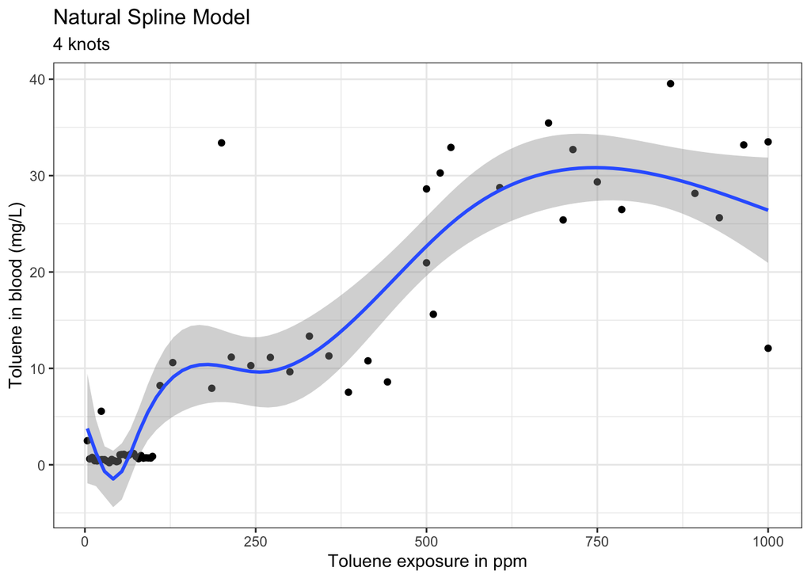

```r
# natural spline plot
natural.lin <- lm(bloodtol ~ ns(newppm, df=5), data=toluene)

toluene %>%
  ggplot(aes(x = newppm, y = bloodtol)) +
  theme_bw() +
  geom_point() +
  labs(y = "Toluene in blood (mg/L)",
       x = "Toluene exposure in ppm",
       title = "Natural Spline Model",
       subtitle = "4 knots") +
  geom_smooth(method = "lm",
              formula = y ~ ns(x,df = 5))
```

```r
# model output
summary(natural.lin)
```

```
##
## Call:
## lm(formula = bloodtol ~ ns(newppm, df = 5), data = toluene)
##
## Residuals:
##      Min       1Q   Median       3Q      Max
## -14.3227  -2.4858   0.1885   1.6985  23.1489
##
## Coefficients:
##                     Estimate Std. Error t value Pr(>|t|)
## (Intercept)           3.7662     2.8363   1.328  0.18982
## ns(newppm, df = 5)1  10.6075     4.1213   2.574  0.01284 *
## ns(newppm, df = 5)2  -0.6205     5.2506  -0.118  0.90637
## ns(newppm, df = 5)3  35.6143     4.2184   8.443 1.92e-11 ***
## ns(newppm, df = 5)4  19.7430     6.5197   3.028  0.00377 **
## ns(newppm, df = 5)5  26.8920     3.0020   8.958 2.90e-12 ***
## ---
## Signif. codes:  0 '***' 0.001 '**' 0.01 '*' 0.05 '.' 0.1 ' ' 1
##
## Residual standard error: 5.465 on 54 degrees of freedom
## Multiple R-squared:  0.8283, Adjusted R-squared:  0.8124
## F-statistic: 52.11 on 5 and 54 DF,  p-value: < 2.2e-16
```

**Comment:** The fit of this model represents the distribution of observations very well when visually inspected. The spline appears to be robust in fitting the observations and captures the overall shape of the distribution. Outliers have minimal impact on the fit.

## 6. Residual plots for the models fit so far

**Residual plots for each of the models**

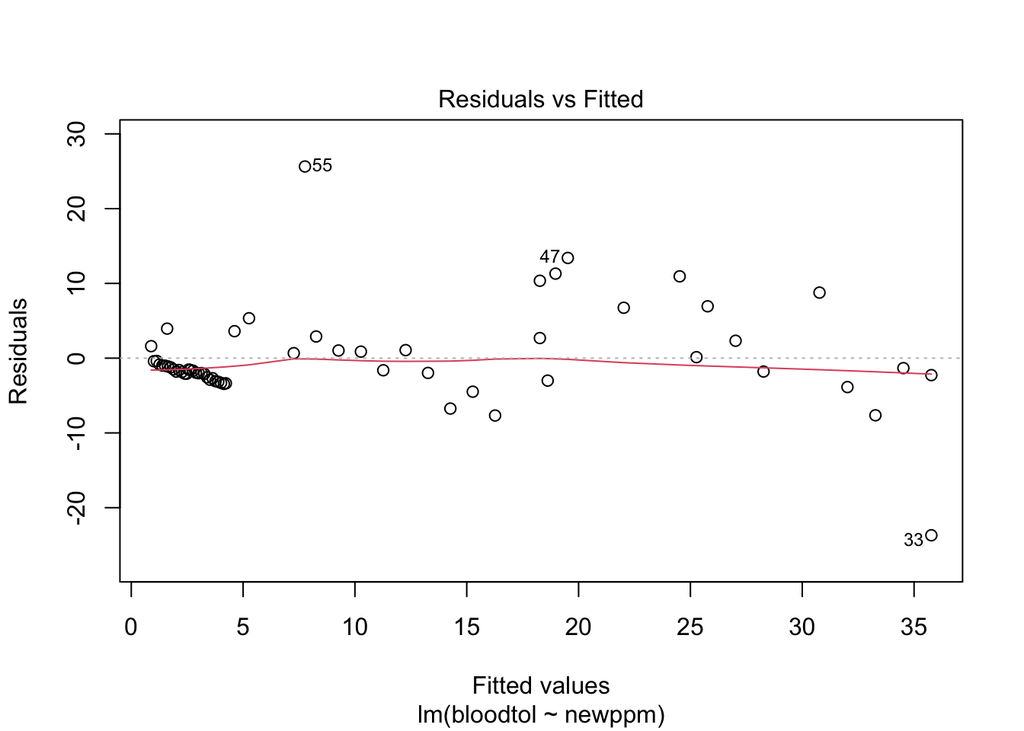

```r
# plots for linear model
# residual vs. fitted. values
resid_fitted <- plot(fit, which=1)
```

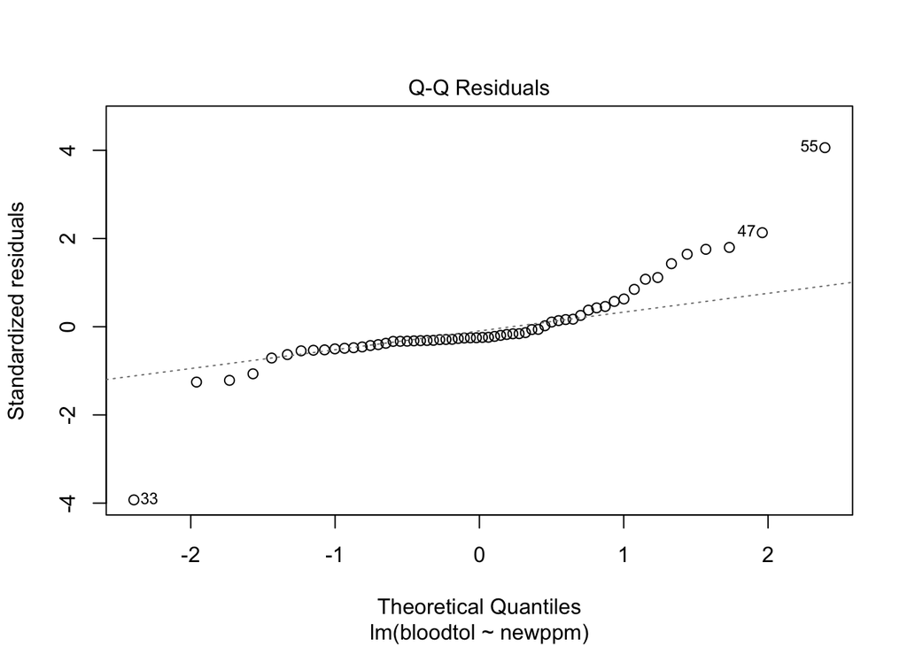

```r
# residual qq plot
resid_qq <- plot(fit, which=2)
```

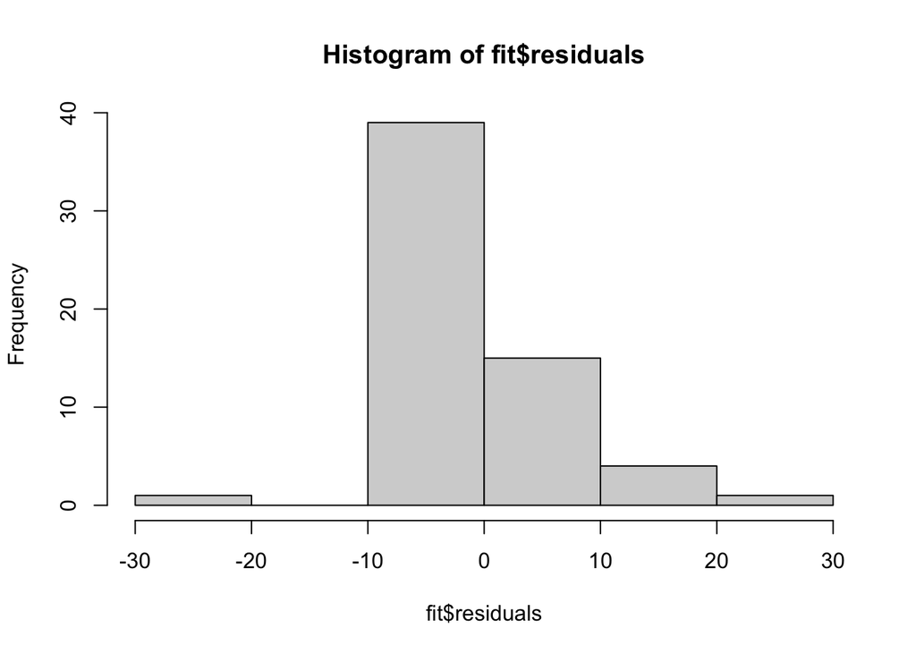

```r
# histogram of residuals
resid_hist <- hist(fit$residuals)
```

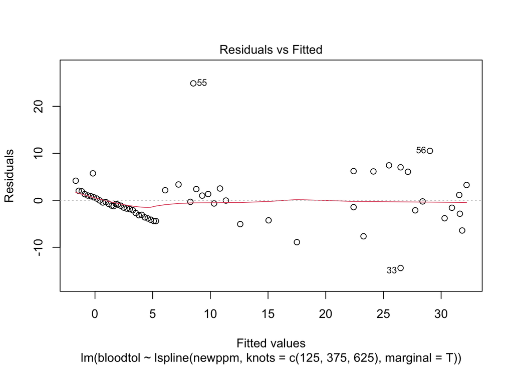

```r
# plots for linear spline model
# residual vs. fitted. values
resid_fitted <- plot(spline.lin.t, which=1)
```

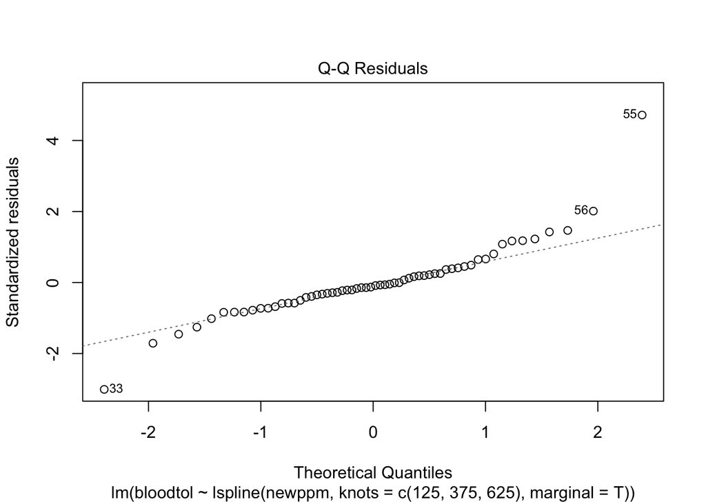

```r
# residual qq plot
resid_qq <- plot(spline.lin.t, which=2)
```

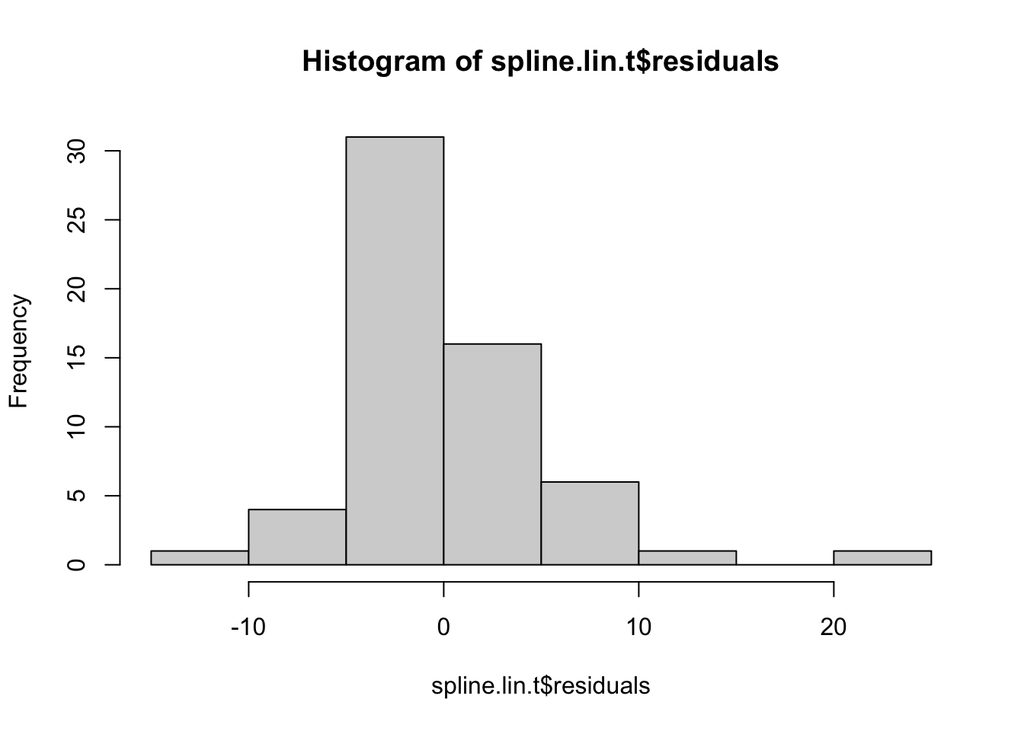

```r
# histogram of residuals
resid_hist <- hist(spline.lin.t$residuals)
```

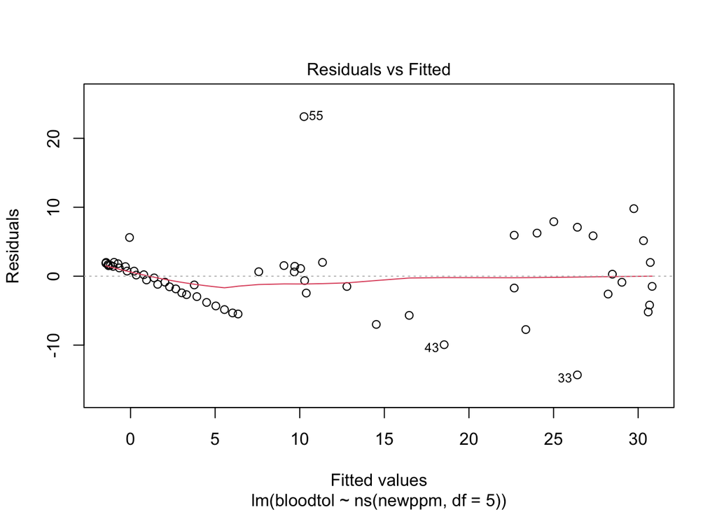

```r
# plots for natural spline model
# residual vs. fitted. values
resid_fitted <- plot(natural.lin, which=1)
```

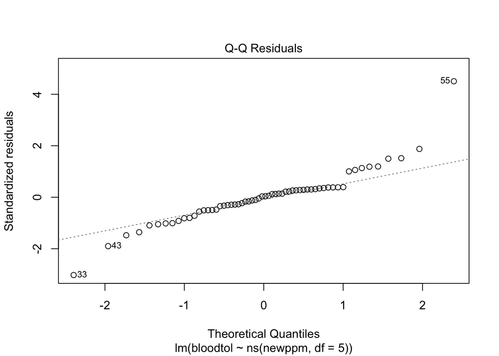

```r
# residual qq plot
resid_qq <- plot(natural.lin, which=2)
```

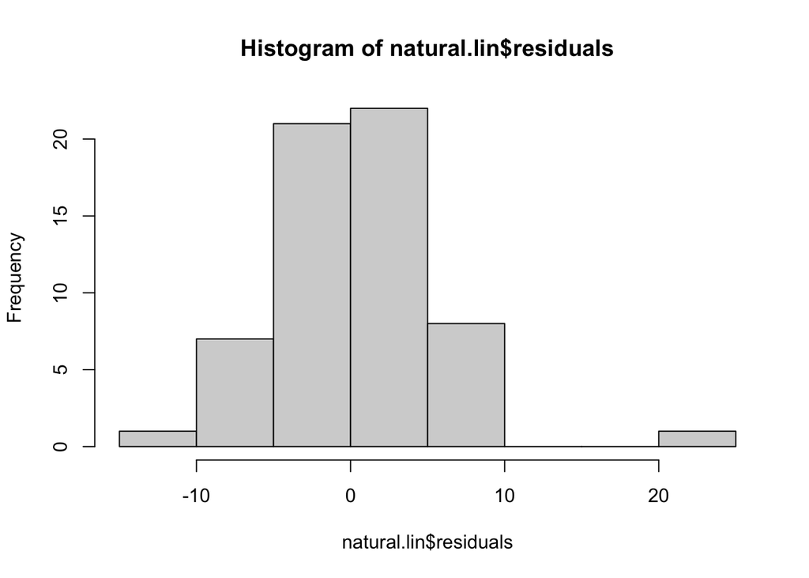

```r
# histogram of residuals
resid_hist <- hist(natural.lin$residuals)
```

**Comment:** The residuals are more extreme for a linear regression, but are similar between a linear spline and natural spline.

## 7. Test for linearity

**Using the linear spline and natural spline models, I ran tests for linearity.**

```r
# test for linearity (linear spline model)
anova(fit, spline.lin.t)
```

|  | Res.Df | RSS | Df | Sum of Sq | F | Pr(>F) |
| --- | --- | --- | --- | --- | --- | --- |
| 1 | 58 | 2356.143 | NA | NA | NA | NA |
| 2 | 55 | 1645.296 | 3 | 710.8465 | 7.920876 | 0.0001760411 |

```r
# test for linearity (natural spline model)
anova(fit, natural.lin)
```

|  | Res.Df | RSS | Df | Sum of Sq | F | Pr(>F) |
| --- | --- | --- | --- | --- | --- | --- |
| 1 | 58 | 2356.143 | NA | NA | NA | NA |
| 2 | 54 | 1612.744 | 4 | 743.3986 | 6.222861 | 0.0003415163 |

**Interpretation:** There were significant difference between linear vs. linear spline model, as well as between linear vs. natural spline model, meaning there is an evidence of non-linearity (p-value=0.00018 for linear spline and p-value=0.00034 for natural spline model).

## 8. Model fit based on various metrics

**Comparing the fits of the linear, linear spline, and natural spline models ($R^2$/adjusted $R^2$ values, mean squared errors, AICs, and BICs).**

```r
# model fit metrics
summary(fit)
```

```
##
## Call:
## lm(formula = bloodtol ~ newppm, data = toluene)
##
## Residuals:
##     Min      1Q  Median      3Q     Max
## -23.688  -2.340  -1.550   1.208  25.635
##
## Coefficients:
##             Estimate Std. Error t value Pr(>|t|)
## (Intercept)  0.76422    1.13233   0.675    0.502
## newppm       0.03501    0.00266  13.163   <2e-16 ***
## ---
## Signif. codes:  0 '***' 0.001 '**' 0.01 '*' 0.05 '.' 0.1 ' ' 1
##
## Residual standard error: 6.374 on 58 degrees of freedom
## Multiple R-squared:  0.7492, Adjusted R-squared:  0.7449
## F-statistic: 173.3 on 1 and 58 DF,  p-value: < 2.2e-16
```

```r
summary(spline.lin.t)
```

```
##
## Call:
## lm(formula = bloodtol ~ lspline(newppm, knots = c(125, 375, 625),
##     marginal = T), data = toluene)
##
## Residuals:
##      Min       1Q   Median       3Q      Max
## -14.4022  -2.7426  -0.5662   1.9372  24.8764
##
## Coefficients:
##                                                          Estimate Std. Error
## (Intercept)                                              -1.92817    1.85437
## lspline(newppm, knots = c(125, 375, 625), marginal = T)1  0.07284    0.02740
## lspline(newppm, knots = c(125, 375, 625), marginal = T)2 -0.05488    0.03828
## lspline(newppm, knots = c(125, 375, 625), marginal = T)3  0.06800    0.02757
## lspline(newppm, knots = c(125, 375, 625), marginal = T)4 -0.10376    0.02524
##                                                          t value Pr(>|t|)
## (Intercept)                                               -1.040 0.302982
## lspline(newppm, knots = c(125, 375, 625), marginal = T)1   2.658 0.010267 *
## lspline(newppm, knots = c(125, 375, 625), marginal = T)2  -1.434 0.157294
## lspline(newppm, knots = c(125, 375, 625), marginal = T)3   2.467 0.016784 *
## lspline(newppm, knots = c(125, 375, 625), marginal = T)4  -4.110 0.000133 ***
## ---
## Signif. codes:  0 '***' 0.001 '**' 0.01 '*' 0.05 '.' 0.1 ' ' 1
##
## Residual standard error: 5.469 on 55 degrees of freedom
## Multiple R-squared:  0.8249, Adjusted R-squared:  0.8121
## F-statistic: 64.76 on 4 and 55 DF,  p-value: < 2.2e-16
```

```r
summary(natural.lin)
```

```
##
## Call:
## lm(formula = bloodtol ~ ns(newppm, df = 5), data = toluene)
##
## Residuals:
##      Min       1Q   Median       3Q      Max
## -14.3227  -2.4858   0.1885   1.6985  23.1489
##
## Coefficients:
##                     Estimate Std. Error t value Pr(>|t|)
## (Intercept)           3.7662     2.8363   1.328  0.18982
## ns(newppm, df = 5)1  10.6075     4.1213   2.574  0.01284 *
## ns(newppm, df = 5)2  -0.6205     5.2506  -0.118  0.90637
## ns(newppm, df = 5)3  35.6143     4.2184   8.443 1.92e-11 ***
## ns(newppm, df = 5)4  19.7430     6.5197   3.028  0.00377 **
## ns(newppm, df = 5)5  26.8920     3.0020   8.958 2.90e-12 ***
## ---
## Signif. codes:  0 '***' 0.001 '**' 0.01 '*' 0.05 '.' 0.1 ' ' 1
##
## Residual standard error: 5.465 on 54 degrees of freedom
## Multiple R-squared:  0.8283, Adjusted R-squared:  0.8124
## F-statistic: 52.11 on 5 and 54 DF,  p-value: < 2.2e-16
```

```r
# nested models tests
anova(fit, spline.lin.t)
```

|  | Res.Df | RSS | Df | Sum of Sq | F | Pr(>F) |
| --- | --- | --- | --- | --- | --- | --- |
| 1 | 58 | 2356.143 | NA | NA | NA | NA |
| 2 | 55 | 1645.296 | 3 | 710.8465 | 7.920876 | 0.0001760411 |

```r
anova(fit, natural.lin)
```

|  | Res.Df | RSS | Df | Sum of Sq | F | Pr(>F) |
| --- | --- | --- | --- | --- | --- | --- |
| 1 | 58 | 2356.143 | NA | NA | NA | NA |
| 2 | 54 | 1612.744 | 4 | 743.3986 | 6.222861 | 0.0003415163 |

```r
# AIC values to compare non-nested models
AIC(fit)
```

```
## [1] 396.4988
```

```r
AIC(spline.lin.t)
```

```
## [1] 380.9525
```

```r
AIC(natural.lin)
```

```
## [1] 381.7535
```

```r
# BIC values to compare non-nested models
BIC(fit)
```

```
## [1] 402.7818
```

```r
BIC(spline.lin.t)
```

```
## [1] 393.5186
```

```r
BIC(natural.lin)
```

```
## [1] 396.4139
```

```r
# print multiple model metrics
broom::glance(fit)
```

| r.squared | adj.r.squared | sigma | statistic | p.value | df | logLik | AIC | BIC | deviance | df.residual | nobs |
| --- | --- | --- | --- | --- | --- | --- | --- | --- | --- | --- | --- |
| 0.7492044 | 0.7448803 | 6.373629 | 173.264 | 4.559753e-19 | 1 | -195.2494 | 396.4988 | 402.7818 | 2356.143 | 58 | 60 |

```r
broom::glance(spline.lin.t)
```

| r.squared | adj.r.squared | sigma | statistic | p.value | df | logLik | AIC | BIC | deviance | df.residual | nobs |
| --- | --- | --- | --- | --- | --- | --- | --- | --- | --- | --- | --- |
| 0.8248692 | 0.8121325 | 5.469413 | 64.76276 | 3.689099e-20 | 4 | -184.4762 | 380.9525 | 393.5186 | 1645.296 | 55 | 60 |

```r
broom::glance(natural.lin)
```

| r.squared | adj.r.squared | sigma | statistic | p.value | df | logLik | AIC | BIC | deviance | df.residual | nobs |
| --- | --- | --- | --- | --- | --- | --- | --- | --- | --- | --- | --- |
| 0.8283342 | 0.8124392 | 5.464945 | 52.11293 | 1.868239e-19 | 5 | -183.8767 | 381.7535 | 396.4139 | 1612.744 | 54 | 60 |

**Comparison:** The R-square and adjusted R-square are 0.75 and 0.74 for the linear model, 0.82 and 0.81 for the linear spline model, and 0.83 and 0.81 for the natural spline model, respectively. The mean squared errors are 40.6, 29.9, and 29.9 respectively. AICs are 396.5, 381.0, and 381.8 respectively. BICs are 402.8, 393.5, and 396.4 respectively.

# Part 2: NHANES Study

The following data come from the NHANES study. We are interested in estimating ferritin levels based on a handful of covariates in the data.

## Data management

```r
# load in data
nhanes = read_csv("nhanes_subset.csv")
```

## 1. Full model

**Fitting a multiple linear regression to estimate ferritin with all predictors in the data set.**

```r
# fit max model
full <- lm(ferritin ~ ., data=nhanes)
summary(full)
```

```
##
## Call:
## lm(formula = ferritin ~ ., data = nhanes)
##
## Residuals:
##     Min      1Q  Median      3Q     Max
## -248.02  -63.40  -24.70   26.56 1391.30
##
## Coefficients:
##                      Estimate Std. Error t value Pr(>|t|)
## (Intercept)         8.857e+02  3.825e+02   2.315  0.02082 *
## sexMale             1.082e+02  1.371e+01   7.894 8.92e-15 ***
## age                 9.127e-01  3.909e-01   2.335  0.01978 *
## creatinine_urine    4.002e-05  6.390e-04   0.063  0.95008
## alcohol_daily       1.593e+00  2.674e+00   0.596  0.55157
## weight              5.510e+00  2.085e+00   2.643  0.00836 **
## height             -6.346e+00  2.221e+00  -2.857  0.00438 **
## bmi                -1.832e+01  5.894e+00  -3.108  0.00195 **
## arm_circ            1.732e+00  2.330e+00   0.743  0.45764
## waist_circ          1.255e+00  8.821e-01   1.423  0.15521
## pulse              -1.273e-01  4.555e-01  -0.280  0.77987
## glycohemoglobin    -2.482e+00  5.552e+00  -0.447  0.65500
## insuredYes          2.020e+01  1.375e+01   1.469  0.14224
## insulin             3.374e-02  4.911e-02   0.687  0.49218
## vigorous_paYes      1.121e+01  1.111e+01   1.009  0.31331
## chol                4.541e+00  4.508e+00   1.007  0.31400
## sbp                 1.141e+00  3.763e-01   3.032  0.00250 **
## dbp                -5.926e-01  5.260e-01  -1.127  0.26022
## cvdYes             -2.269e+01  1.745e+01  -1.300  0.19391
## phq9                1.909e+00  1.127e+00   1.694  0.09054 .
## smokerNever-smoker -1.068e+01  9.843e+00  -1.085  0.27803
## ---
## Signif. codes:  0 '***' 0.001 '**' 0.01 '*' 0.05 '.' 0.1 ' ' 1
##
## Residual standard error: 134.5 on 857 degrees of freedom
## Multiple R-squared:  0.1998, Adjusted R-squared:  0.1811
## F-statistic:  10.7 on 20 and 857 DF,  p-value: < 2.2e-16
```

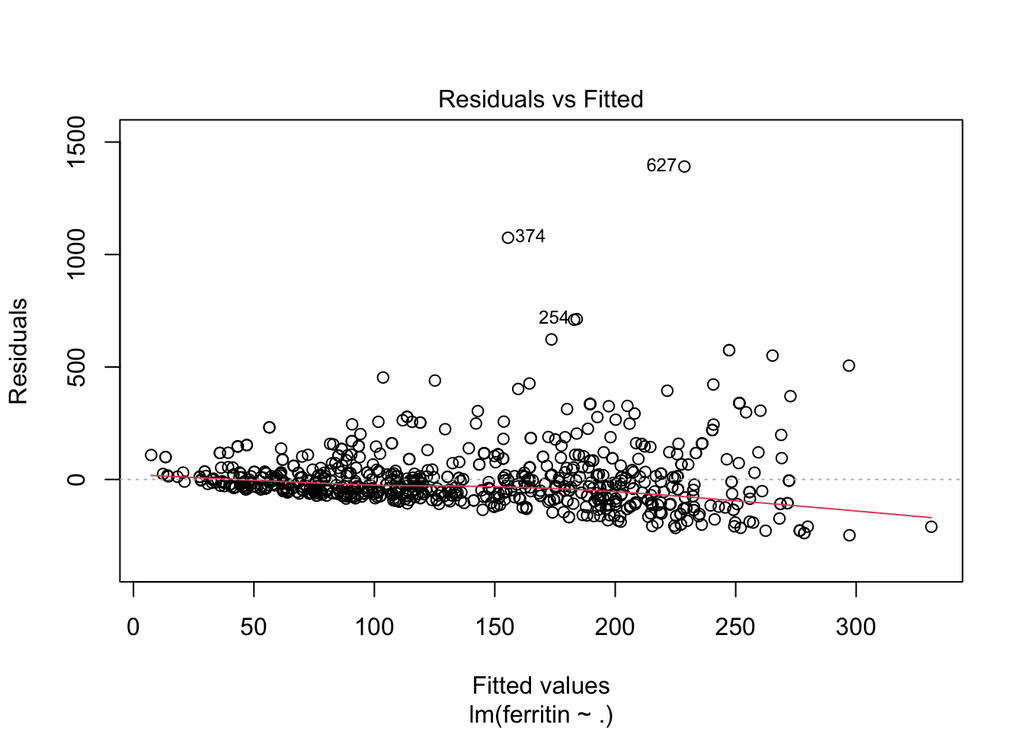

```r
# residual plots
# residual vs. fitted. values
resid_fitted <- plot(full, which=1)
```

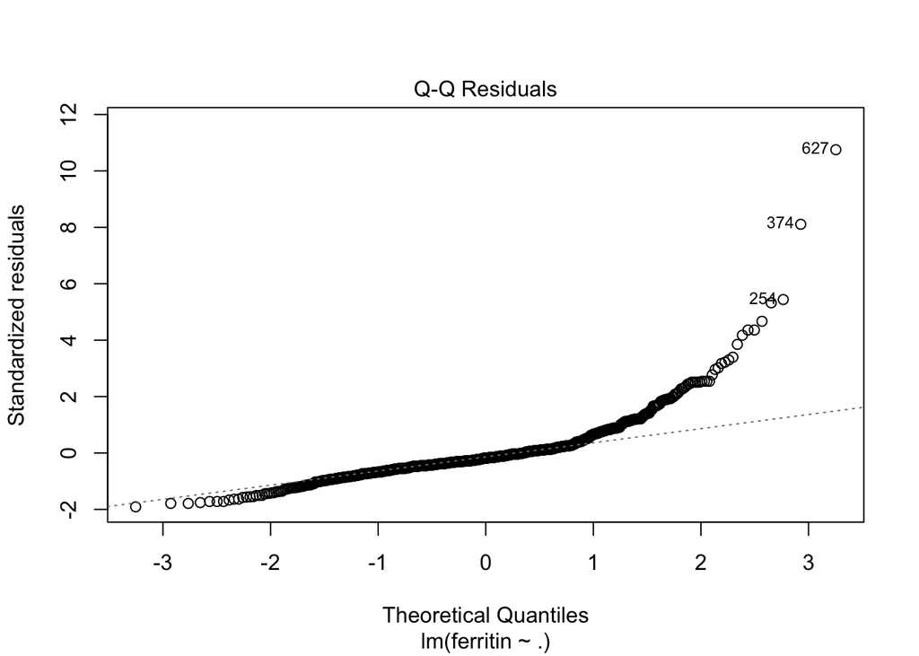

```r
# residual qq plot
resid_qq <- plot(full, which=2)
```

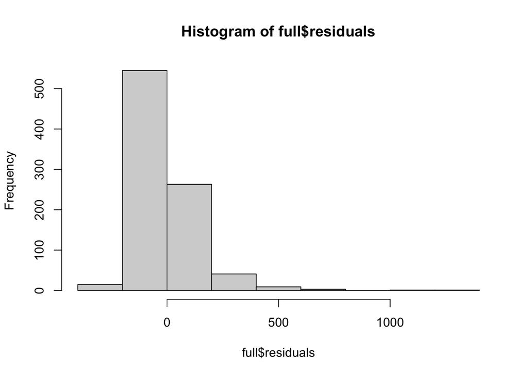

```r
# histogram of residuals
resid_hist <- hist(full$residuals)
```

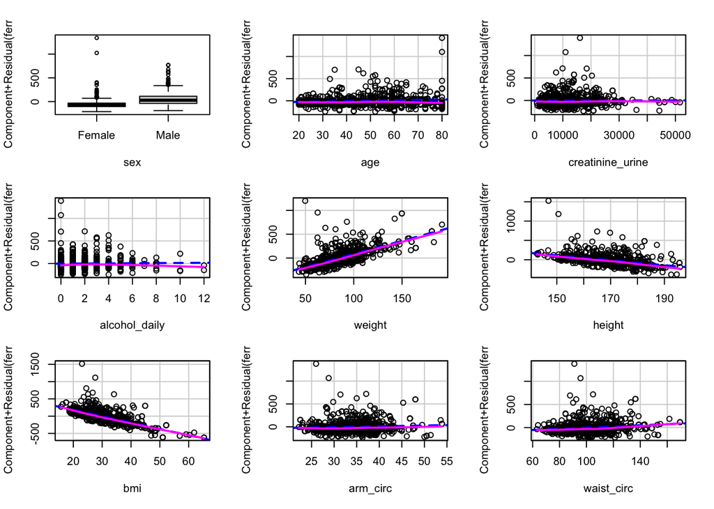

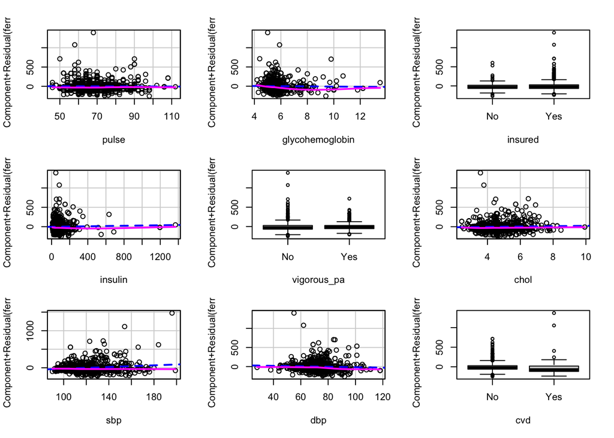

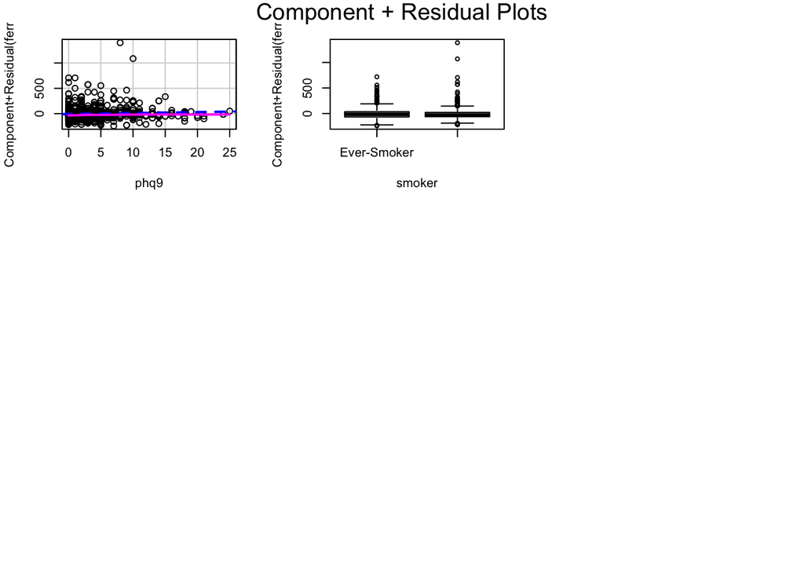

```r
# C+R plots
crPlots(full)
```

**Comment:** There are several extreme outliers shown from the residuals plot. Creatinine, urine, glycohemoglobin and insulin have right tails thus need to be log transformed.

## Transforming Variables

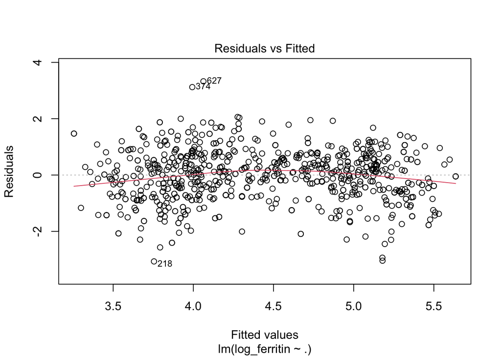

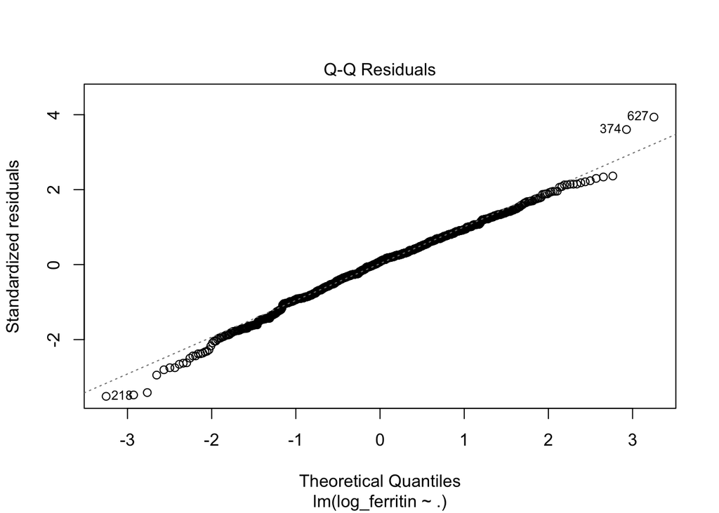

```r
# log transforming and dropping un-transformed values
nhanes = nhanes %>%
  mutate(log_creatinine_urine = log(creatinine_urine),
         log_insulin = log(insulin),
         log_ferritin = log(ferritin),
         log_ghb = log(glycohemoglobin)) %>%
  dplyr::select(-c(creatinine_urine, insulin, ferritin, glycohemoglobin)) # remove original variables

# refit model with all predictors
maxmodel_log = lm(log_ferritin ~ ., data = nhanes)

# check model fit and check for influential points
# residual plots
plot(maxmodel_log, which = 1:2)
```

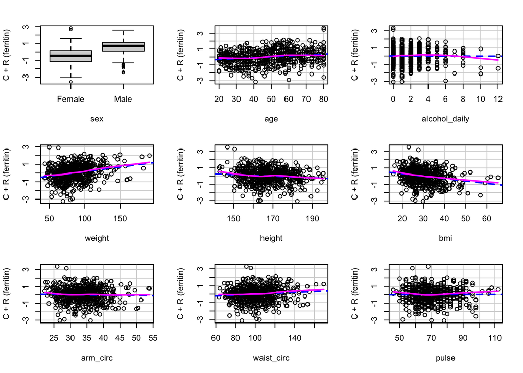

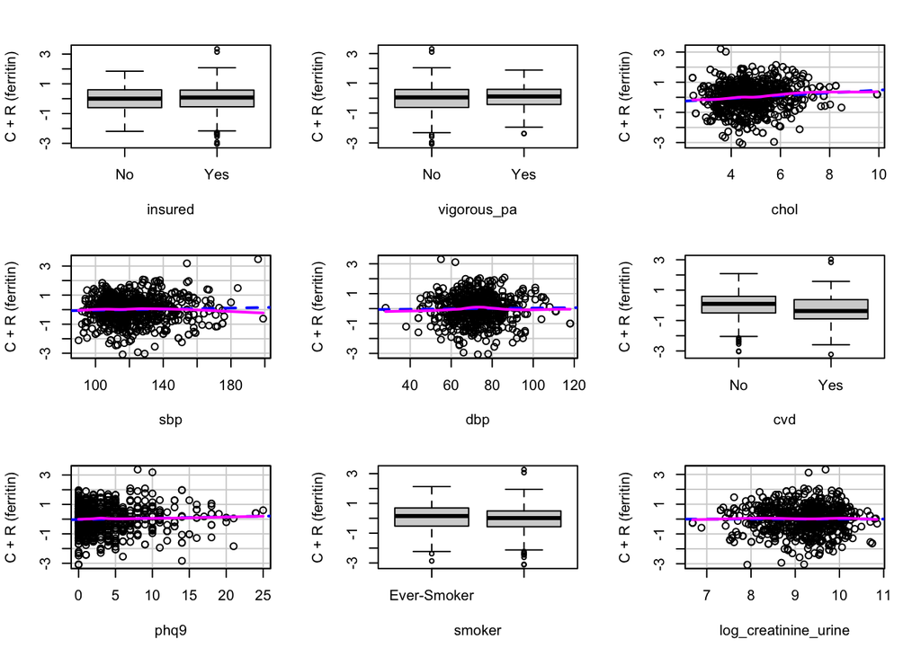

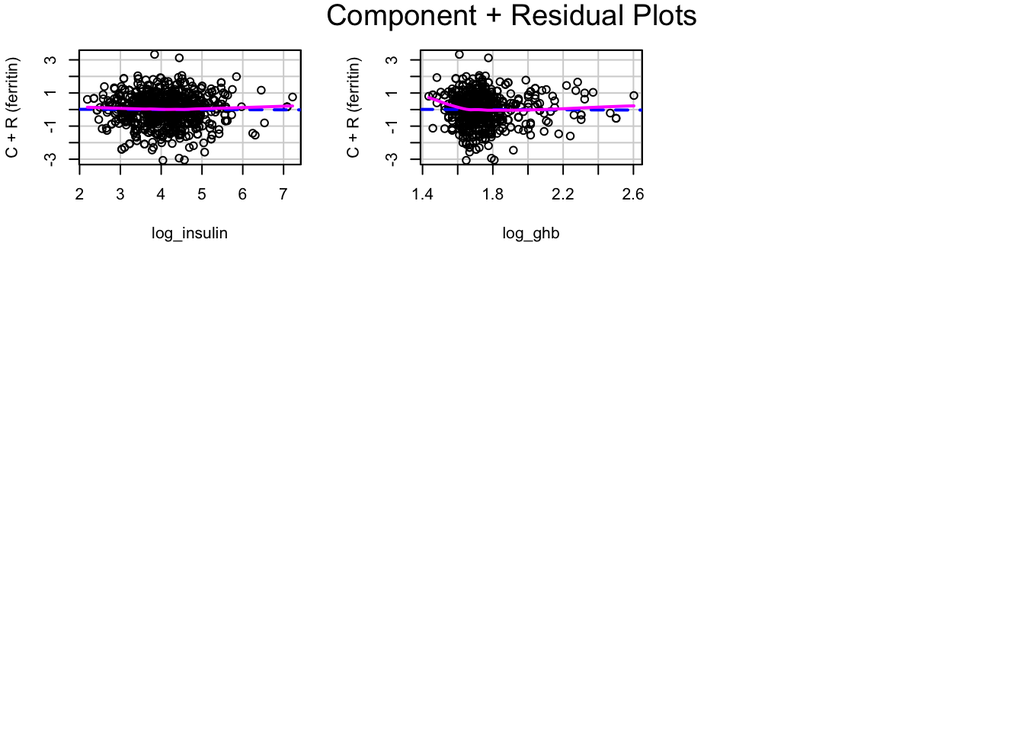

```r
# C+R plots
crPlots(maxmodel_log, ylab = "C + R (ferritin)")
```

## 2. VIF

**Checking for collinearity in the model with all predictors included.**

```r
# check for collinearity
full_col <- vif(maxmodel_log)
full_col
```

```
##                  sex                  age        alcohol_daily
##             2.287607             2.042765             1.155138
##               weight               height                  bmi
##           104.725516            21.961649            86.652202
##             arm_circ           waist_circ                pulse
##             6.850628            11.298078             1.196627
##              insured          vigorous_pa                 chol
##             1.198919             1.234011             1.068690
##                  sbp                  dbp                  cvd
##             1.967631             1.636772             1.139369
##                 phq9               smoker log_creatinine_urine
##             1.081343             1.153497             1.171515
##          log_insulin              log_ghb
##             1.790023             1.359053
```

**Comments:** The vifs are high in weight, height, bmi, arm circumference, and waist circumference. Thus, the collinearity could affect our statistical inference.

## 3. Variable selection

**Running backward selection as well as cross-validated (10-fold) lasso regression, ridge regression, and elastic net to choose a model from the full set of covariates used in the previous section.**

```r
set.seed(123)

# backward selection
backward <- suppressWarnings(ols_step_backward_p(maxmodel_log))
backward$model
```

```
##
## Call:
## lm(formula = paste(response, "~", paste(c(include, cterms), collapse = " + ")),
##     data = l)
##
## Coefficients:
##        (Intercept)             sexMale                 age          waist_circ
##           2.243793            1.043679            0.010944            0.004040
##         insuredYes                chol                 sbp              cvdYes
##           0.125561            0.092938            0.002366           -0.323396
##               phq9  smokerNever-smoker
##           0.009277           -0.117003
```

```r
backward$metrics
```

| step | variable | r2 | adj_r2 | aic | sbc | sbic | mallows_cp | rmse |
| --- | --- | --- | --- | --- | --- | --- | --- | --- |
| 1 | log_creatinine_urine | 0.3145524 | 0.2993735 | 2287.273 | 2387.603 | -203.4043 | 19.0006322 | 0.8690894 |
| 2 | log_insulin | 0.3145430 | 0.3001796 | 2285.285 | 2380.838 | -205.4418 | 17.0123391 | 0.8690953 |
| 3 | pulse | 0.3145310 | 0.3009810 | 2283.300 | 2374.076 | -207.4760 | 15.0273961 | 0.8691029 |
| 4 | log_ghb | 0.3145149 | 0.3017765 | 2281.321 | 2367.319 | -209.5052 | 13.0474996 | 0.8691131 |
| 5 | alcohol_daily | 0.3144954 | 0.3025666 | 2279.346 | 2360.566 | -211.5299 | 11.0719446 | 0.8691255 |
| 6 | arm_circ | 0.3144137 | 0.3032918 | 2277.451 | 2353.893 | -213.4779 | 9.1740344 | 0.8691773 |
| 7 | dbp | 0.3142957 | 0.3039784 | 2275.602 | 2347.266 | -215.3802 | 7.3216102 | 0.8692521 |
| 8 | vigorous_pa | 0.3139745 | 0.3044573 | 2274.013 | 2340.900 | -217.0297 | 5.7232076 | 0.8694557 |
| 9 | height | 0.3136712 | 0.3049534 | 2272.401 | 2334.510 | -218.6997 | 4.1024138 | 0.8696478 |
| 10 | weight | 0.3135134 | 0.3055955 | 2270.603 | 2327.934 | -220.5495 | 2.2996204 | 0.8697478 |

[output cut: 1 more lines]

```r
X = model.matrix(maxmodel_log)[,-1]
Y = maxmodel_log$model$log_ferritin

# fit lasso
lasso.cv = cv.glmnet(y = Y, x = X, family = "gaussian", alpha = 1)
coef(lasso.cv, s = lasso.cv$lambda.min)
```

```
## 21 x 1 sparse Matrix of class "dgCMatrix"
##                       s=0.01674676
## (Intercept)           2.5027768465
## sexMale               1.0011389802
## age                   0.0103186768
## alcohol_daily         .
## weight                .
## height                0.0001228984
## bmi                   .
## arm_circ              .
## waist_circ            0.0032860423
## pulse                 .
## insuredYes            0.0714160584
## vigorous_paYes        .
## chol                  0.0784759320
## sbp                   0.0015821705
## dbp                   0.0006959628
## cvdYes               -0.2297922832
## phq9                  0.0044559108
## smokerNever-smoker   -0.0899418269
## log_creatinine_urine  .
## log_insulin           .
## log_ghb               .
```

```r
# fit ridge
ridge.cv = cv.glmnet(y = Y, x = X, family = "gaussian", alpha = 0)
coef(ridge.cv, s = ridge.cv$lambda.min)
```

```
## 21 x 1 sparse Matrix of class "dgCMatrix"
##                       s=0.07594451
## (Intercept)           1.5449698985
## sexMale               0.8956213832
## age                   0.0105844898
## alcohol_daily        -0.0014848990
## weight                0.0010190557
## height                0.0040237337
## bmi                  -0.0031226212
## arm_circ             -0.0006945290
## waist_circ            0.0037365011
## pulse                -0.0001207272
## insuredYes            0.1011865625
## vigorous_paYes        0.0339782429
## chol                  0.0876119408
## sbp                   0.0025960952
## dbp                   0.0013439390
## cvdYes               -0.2824774611
## phq9                  0.0073718851
## smokerNever-smoker   -0.1231989549
## log_creatinine_urine  0.0081237966
## log_insulin           0.0021275879
## log_ghb               0.0089803826
```

```r
# elastic net (use alpha = 0.5 for this)
enet.cv = cv.glmnet(y = Y, x = X, family = "gaussian", alpha = 0.5)
coef(enet.cv, s = enet.cv$lambda.min)
```

```
## 21 x 1 sparse Matrix of class "dgCMatrix"
##                       s=0.03349352
## (Intercept)           2.3620236771
## sexMale               0.9701163303
## age                   0.0101877420
## alcohol_daily         .
## weight                0.0001428003
## height                0.0011033488
## bmi                   .
## arm_circ              .
## waist_circ            0.0030161664
## pulse                 .
## insuredYes            0.0671768160
## vigorous_paYes        .
## chol                  0.0774365521
## sbp                   0.0017645005
## dbp                   0.0006915222
## cvdYes               -0.2229551551
## phq9                  0.0040483431
## smokerNever-smoker   -0.0910145550
## log_creatinine_urine  .
## log_insulin           .
## log_ghb               .
```

**Comment:** The backwards model selection was the most strict on selecting variables. The ridge regression was the least strict on selecting variables. The lasso and elastic net were less strict than backwards model but stricter than the ridge model. The magnitude of the coefficients for the variables selected were similar between the different models used.

## 4. VIFs and model selection

At least 2 or 3 of the variables that had high collinearity were removed from the models. It can distort the observed effect of the variables if they all remain in the model, so by removing them it is easier to examine the individual effects of variables in the models.

## 5. Compare model fit

**Comparing the model fit from the final models from lasso, ridge, and elastic net.**

```r
# MSEs from the 3 different models
lasso.cv$index[1]
```

```
## [1] 38
```

```r
ridge.cv$index[1]
```

```
## [1] 96
```

```r
enet.cv$index[1]
```

```
## [1] 38
```

```r
lasso.cv$cvm[38]
```

```
## [1] 0.7825408
```

```r
ridge.cv$cvm[96]
```

```
## [1] 0.7911054
```

```r
enet.cv$cvm[38]
```

```
## [1] 0.7782942
```

```r
# R2 values
lasso.cv$glmnet.fit$dev.ratio[38]
```

```
## [1] 0.3113098
```

```r
ridge.cv$glmnet.fit$dev.ratio[96]
```

```
## [1] 0.3119663
```

```r
enet.cv$glmnet.fit$dev.ratio[38]
```

```
## [1] 0.3108198
```

**Decision:** The elastic net model would be my choice. The result of the elastic net model had the lowest MSE compared to lasso or ridge regression models. The R-square of the elastic model was not the highest, but it was still similar to others.